# Analyse descriptive de l’AVC et de ses facteurs de risque — 中风与危险混杂因素的描述性分析

Version R · 中法双语 / Bilingue 中文-Français

2026-09-20

# 📌 先看这里 / À lire d’abord

**数据 / Données** : `healthcare-dataset-stroke-data.csv` — 5 110 lignes / 行 × 12 colonnes / 列

> ⚠️ **中文**：这是**观察性、横断面**数据（一次快照，没有时间先后）。只能得出「**关联**」，不能得出「**因果**」。 **Français** : données **observationnelles et transversales** (un instantané). On ne conclut qu’à des **associations**, jamais à une **causalité**.

## 如何使用 / Mode d’emploi

1. **中文**：把 csv 与本 `.Rmd` 放在**同一文件夹**，用 RStudio 打开，点击 **Knit ▸ Knit to HTML**，得到带目录的网页。 **Français** : placez le csv dans le **même dossier** que ce `.Rmd`, ouvrez-le dans RStudio, cliquez **Knit ▸ Knit to HTML**.
2. **中文**：想边学边跑？在 `.Rmd` 里点每个代码块右上角的 ▶（或 `Ctrl+Shift+Enter`）逐块运行。 **Français** : pour apprendre pas à pas, exécutez chaque bloc avec ▶ (ou `Ctrl+Shift+Enter`).
3. **中文**：网页右上角的 **Code ▾ → Hide All Code** 可以一键折叠/展开所有代码，方便只读结论。 **Français** : en haut à droite, **Code ▾ → Hide All Code** replie/déplie tout le code.
4. **中文**：每一步先**自己预测结果**，再看输出。最后一节有「自动验算」，确认你的结果与参考值一致。 **Français** : pour chaque étape, **prédisez d’abord**. La dernière section propose une « vérification automatique ».
5. **中文**：中文乱码？`File ▸ Reopen with Encoding ▸ UTF-8`。建议 R ≥ 4.2。图中文字为法语，避免字体问题。 **Français** : caractères chinois illisibles ? `File ▸ Reopen with Encoding ▸ UTF-8`. R ≥ 4.2 conseillé. Les graphiques sont en français (pas de souci de police).

## 速查表 / Aide-mémoire

| 步骤 Étape | 做什么 / Objectif | 关键 R 函数 / Fonctions R clés |
| --- | --- | --- |
| 0 | 定义问题与预测 / questions et prédictions | （无代码 / pas de code） |
| 1 | 读数据、数据字典 / lecture, dictionnaire | `read_csv()`, `glimpse()` |
| 2 | 质量审计 / audit qualité | `is.na()`, `colSums()`, `group_by()` + `summarise()`, `count()` |
| 3 | 人群与变量处理 / population et variables | `filter()`, `mutate()`, `cut()`, `factor()` |
| 4 | 表 1 / Tableau 1 | `median()`, `quantile()`, `wilcox.test()`, `chisq.test()` |
| 5 | 双变量：率 + 置信区间 / taux + IC | `prop.test(correct = FALSE)`（Wilson）, `table()`, `ggplot()` |
| 6 | 混杂：分层与调整 / confusion | `mantelhaen.test()`, `glm(family = binomial)`, `confint.default()` |
| 6bis | 敏感性分析 / sensibilité | `ifelse()`, `median(na.rm = TRUE)`, `update()` |
| 7–8 | 呈现与结论 / présentation | `ggsave()`, `knitr::kable()` |

## 术语对照 / Glossaire

| 中文 | Français | English |
| --- | --- | --- |
| 中风 | AVC (accident vasculaire cérébral) | stroke |
| 混杂因素 | facteur de confusion | confounder |
| 中介变量 | variable médiatrice | mediator |
| 优势比 | rapport de cotes (*odds ratio*, OR) | odds ratio |
| 95% 置信区间 | intervalle de confiance à 95 % (IC 95 %) | 95% CI |
| 分层分析 | analyse stratifiée | stratified analysis |
| 敏感性分析 | analyse de sensibilité | sensitivity analysis |
| 缺失值 / 异常值 | valeurs manquantes / aberrantes | missing / outliers |
| 横断面研究 | étude transversale | cross-sectional study |
| 反向因果 | causalité inverse | reverse causation |
| 分母 | dénominateur | denominator |
| 中位数（四分位距） | médiane (écart interquartile) | median (IQR) |

## 如果你之前用过 Python(pandas) / Correspondances pandas ↔︎ dplyr

| pandas | R (dplyr / base) |
| --- | --- |
| `df[df.age >= 18]` | `filter(df, age >= 18)` |
| `df.assign(x = ...)` | `mutate(df, x = ...)` |
| `df.groupby(g).agg(...)` | `df %>% group_by(g) %>% summarise(...)` |
| `pd.cut(x, bins)` | `cut(x, breaks = ...)` |
| `pd.crosstab(a, b)` | `table(a, b)` |
| `df.pivot(...)` | `pivot_wider(...)` |
| `df.value_counts()` | `count(df, x)` |

# Étape 0 — Définir la question / 第 0 步：先定义问题，再写代码

**中文**：「描述性分析」回答**「是什么」**，不回答**「为什么」**。我们可以描述：谁中风了、他们有什么特征、哪些因素与中风同时出现、控制年龄后这种关联是否还在。我们**不能**说「X 导致中风」。

**Français** : l’analyse descriptive répond à **« quoi ? »**, pas à **« pourquoi ? »**. On peut décrire qui a eu un AVC, leurs caractéristiques, quels facteurs coexistent avec l’AVC, et si l’association persiste **après contrôle de l’âge**. On **ne peut pas** affirmer « X provoque l’AVC ».

| # | 中文 | Français |
| --- | --- | --- |
| Q1 | 中风比例随**年龄**如何变化？ | Comment la proportion d’AVC varie-t-elle avec l’**âge** ? |
| Q2 | 高血压、心脏病、高血糖、肥胖、吸烟各自与中风的关联有多强？ | Quelle est la force d’association de l’hypertension, des cardiopathies, de l’hyperglycémie, de l’obésité et du tabac avec l’AVC ? |
| Q3 | 这些关联在**控制年龄之后**是否依然存在？ | Ces associations persistent-elles **après ajustement sur l’âge** ? |
| Q4 | 危险因素**叠加**时，中风比例如何变化？ | Que devient la proportion d’AVC quand les facteurs de risque **s’accumulent** ? |

### ✍️ 你来练习 / À vous de jouer

**中文**：在下面的代码块里写下你的**预测**（看到结果之前！）。这是证明「思考是你的」的第一份证据。 **Français** : écrivez vos **prédictions** ci-dessous (avant de voir les résultats !). C’est la première preuve que la réflexion est bien la vôtre.

```r
# 你的预测 / Vos prédictions — 请修改引号里的文字 / modifiez le texte entre guillemets
date_prediction <- "AAAA-MM-JJ"    # 填写今天日期 / mettez la date du jour

hypotheses <- c(
  "H1 (age)"        = "在这里写下预测 / écrivez votre prédiction ici",
  "H2 (facteurs)"   = "哪个因素关联最强？/ quel facteur sera le plus fortement associé ?",
  "H3 (ajustement)" = "控制年龄后哪些关联会变弱？/ quelles associations s'affaibliront après ajustement ?",
  "H4 (cumul)"      = "叠加危险因素会怎样？/ que se passe-t-il quand les facteurs s'accumulent ?"
)
cat("Prédictions du / 预测日期 :", date_prediction, "\n")
```

```
## Prédictions du / 预测日期 : AAAA-MM-JJ
```

```r
for (k in names(hypotheses)) cat(" ", k, "→", hypotheses[[k]], "\n")
```

```
##   H1 (age) → 在这里写下预测 / écrivez votre prédiction ici
##   H2 (facteurs) → 哪个因素关联最强？/ quel facteur sera le plus fortement associé ?
##   H3 (ajustement) → 控制年龄后哪些关联会变弱？/ quelles associations s'affaibliront après ajustement ?
##   H4 (cumul) → 叠加危险因素会怎样？/ que se passe-t-il quand les facteurs s'accumulent ?
```

# Étape 1 — Lire les données / 第 1 步：读数据、读懂每一列

**中文**：先建立「数据字典」：含义、类型、以及**不确定的地方**（将来写进「局限性」）。 **Français** : construisez un « dictionnaire de données » : sens, type et **zones d’incertitude** (à reporter dans les limites).

## 1.1 安装与加载包 / Installer et charger les packages

```r
# 只需运行一次（在 Console 中）。eval=FALSE 表示 Knit 时不会执行。
# À exécuter UNE fois dans la Console. eval=FALSE : non exécuté au Knit.
install.packages(c("dplyr", "tidyr", "ggplot2", "readr", "knitr"))
```

```r
library(dplyr)     # 数据处理 / manipulation de données
library(tidyr)     # 长宽表转换 / passage long <-> large
library(ggplot2)   # 画图 / graphiques
library(readr)     # 读 csv / lecture csv
library(tibble)    # tibble() 表格 / tableaux tibble
library(knitr)     # 漂亮的表格 / jolis tableaux

options(dplyr.summarise.inform = FALSE, scipen = 999)
theme_set(theme_minimal(base_size = 11))   # 统一图形主题 / thème graphique commun

fig_dir <- "figures"                        # 图片保存目录 / dossier des figures
dir.create(fig_dir, showWarnings = FALSE)

# 小工具：统一的表格输出 / utilitaire : sortie de tableau uniforme
kt <- function(x, digits = 2, ...) knitr::kable(x, digits = digits, ...)
# 小工具：格式化 p 值 / utilitaire : formater une p-valeur
fmt_p <- function(p) ifelse(is.na(p), "", ifelse(p < 0.001, "<0.001", sprintf("%.3f", p)))
```

## 1.2 读取数据 / Lecture

```r
# 依次尝试几个路径 / on essaie plusieurs chemins
candidates <- c("healthcare-dataset-stroke-data.csv",
                "data/healthcare-dataset-stroke-data.csv")
data_path <- candidates[file.exists(candidates)][1]
if (is.na(data_path)) {
  stop("找不到 csv：请放在与 .Rmd 相同的文件夹 / CSV introuvable : placez-le à côté du .Rmd")
}

# ⚠ R 特有的坑：这份 csv 用 "N/A" 表示缺失，而 read_csv 默认只认 "NA"。
#   若不指定 na=，bmi 会被读成文字！
# ⚠ Piège propre à R : ce csv note les manquants "N/A" alors que read_csv attend "NA".
#   Sans l'argument na=, la colonne bmi serait lue comme du texte !
df_raw <- read_csv(data_path, na = c("", "NA", "N/A"), show_col_types = FALSE)

# 自检：这两条通不过就说明读入有问题 / auto-contrôle : si ces lignes échouent, la lecture est incorrecte
stopifnot(is.numeric(df_raw$bmi), nrow(df_raw) == 5110, sum(df_raw$stroke) == 249)

df <- df_raw   # 工作副本（R 是「复制修改」，不会改动 df_raw）/ copie de travail (R ne modifie pas df_raw)
cat("Fichier / 文件 :", data_path, "\n")
```

```
## Fichier / 文件 : healthcare-dataset-stroke-data.csv
```

```r
cat("Dimensions / 维度 :", nrow(df), "lignes x", ncol(df), "colonnes\n")
```

```
## Dimensions / 维度 : 5110 lignes x 12 colonnes
```

```r
glimpse(df)
```

```
## Rows: 5,110
## Columns: 12
## $ id                <dbl> 9046, 51676, 31112, 60182, 1665, 56669, 53882, 10434…
## $ gender            <chr> "Male", "Female", "Male", "Female", "Female", "Male"…
## $ age               <dbl> 67, 61, 80, 49, 79, 81, 74, 69, 59, 78, 81, 61, 54, …
## $ hypertension      <dbl> 0, 0, 0, 0, 1, 0, 1, 0, 0, 0, 1, 0, 0, 0, 0, 1, 0, 1…
## $ heart_disease     <dbl> 1, 0, 1, 0, 0, 0, 1, 0, 0, 0, 0, 1, 0, 1, 1, 0, 1, 0…
## $ ever_married      <chr> "Yes", "Yes", "Yes", "Yes", "Yes", "Yes", "Yes", "No…
## $ work_type         <chr> "Private", "Self-employed", "Private", "Private", "S…
## $ Residence_type    <chr> "Urban", "Rural", "Rural", "Urban", "Rural", "Urban"…
## $ avg_glucose_level <dbl> 228.69, 202.21, 105.92, 171.23, 174.12, 186.21, 70.0…
## $ bmi               <dbl> 36.6, NA, 32.5, 34.4, 24.0, 29.0, 27.4, 22.8, NA, 24…
## $ smoking_status    <chr> "formerly smoked", "never smoked", "never smoked", "…
## $ stroke            <dbl> 1, 1, 1, 1, 1, 1, 1, 1, 1, 1, 1, 1, 1, 1, 1, 1, 1, 1…
```

## 1.3 数据字典 / Dictionnaire de données

```r
data_dictionary <- data.frame(
  Variable = c("id", "gender", "age", "hypertension", "heart_disease", "ever_married",
               "work_type", "Residence_type", "avg_glucose_level", "bmi", "smoking_status", "stroke"),
  Signification = c(
    "唯一编号 / identifiant unique",
    "性别 / sexe (Male, Female, Other)",
    "年龄（岁）/ âge en années",
    "高血压 0/1 / hypertension",
    "心脏病 0/1 / cardiopathie",
    "是否结过婚 / déjà marié(e)",
    "职业类型 / type d'emploi",
    "居住地 Urban/Rural / lieu de résidence",
    "平均血糖 mg/dL / glycémie moyenne",
    "体重指数 kg/m² / IMC",
    "吸烟状态 / statut tabagique",
    "结局：中风 1 / 否 0 / issue : AVC (1) ou non (0)"),
  A_surveiller = c(
    "不参与分析 / non utilisé",
    "'Other' 仅 1 行 / une seule ligne",
    "小数 = 婴儿 / décimales = nourrissons",
    "诊断史还是当前测量？未说明 / diagnostic ou mesure ? non précisé",
    "定义未说明 / définition non précisée",
    "很可能是年龄的替身 / probablement un substitut de l'âge",
    "'children' ≈ 未成年人 / ≈ mineurs",
    "—",
    "空腹还是随机？未说明 / à jeun ou non ? non précisé",
    "有缺失值 / valeurs manquantes",
    "'Unknown' 含义不清 / 'Unknown' ambigu",
    "本分析的因变量 / variable à expliquer")
)
names(data_dictionary) <- c("变量 Variable", "含义 Signification", "⚠ 需要留意 / À surveiller")
kt(data_dictionary)
```

| 变量 Variable | 含义 Signification | ⚠ 需要留意 / À surveiller |
| --- | --- | --- |
| id | 唯一编号 / identifiant unique | 不参与分析 / non utilisé |
| gender | 性别 / sexe (Male, Female, Other) | ‘Other’ 仅 1 行 / une seule ligne |
| age | 年龄（岁）/ âge en années | 小数 = 婴儿 / décimales = nourrissons |
| hypertension | 高血压 0/1 / hypertension | 诊断史还是当前测量？未说明 / diagnostic ou mesure ? non précisé |
| heart_disease | 心脏病 0/1 / cardiopathie | 定义未说明 / définition non précisée |
| ever_married | 是否结过婚 / déjà marié(e) | 很可能是年龄的替身 / probablement un substitut de l’âge |
| work_type | 职业类型 / type d’emploi | ‘children’ ≈ 未成年人 / ≈ mineurs |
| Residence_type | 居住地 Urban/Rural / lieu de résidence | — |
| avg_glucose_level | 平均血糖 mg/dL / glycémie moyenne | 空腹还是随机？未说明 / à jeun ou non ? non précisé |
| bmi | 体重指数 kg/m² / IMC | 有缺失值 / valeurs manquantes |
| smoking_status | 吸烟状态 / statut tabagique | ‘Unknown’ 含义不清 / ‘Unknown’ ambigu |
| stroke | 结局：中风 1 / 否 0 / issue : AVC (1) ou non (0) | 本分析的因变量 / variable à expliquer |

# Étape 2 — Audit de la qualité / 第 2 步：数据质量审计

**中文**：新手最容易跳过、却最重要的一步。原则：**先怀疑数据，再相信结论**。 **Français** : l’étape la plus souvent sautée, et la plus importante. Principe : **douter des données avant de croire les conclusions**.

## 2.1 基本概况 / Aperçu général

```r
cat("重复的 id / Doublons d'id :", sum(duplicated(df$id)), "\n")
```

```
## 重复的 id / Doublons d'id : 0
```

```r
# 结局分布：注意类别不平衡！/ distribution de l'issue : attention au déséquilibre !
cat(sprintf("中风人数 / Nombre d'AVC : %d / %d = %.2f %%\n",
            sum(df$stroke), nrow(df), mean(df$stroke) * 100))
```

```
## 中风人数 / Nombre d'AVC : 249 / 5110 = 4.87 %
```

```r
# 连续变量概览 / résumé des variables continues
df %>%
  select(age, avg_glucose_level, bmi) %>%
  pivot_longer(everything(), names_to = "variable", values_to = "valeur") %>%
  group_by(variable) %>%
  summarise(n = sum(!is.na(valeur)),
            moyenne = mean(valeur, na.rm = TRUE), ecart_type = sd(valeur, na.rm = TRUE),
            min = min(valeur, na.rm = TRUE), q25 = quantile(valeur, .25, na.rm = TRUE),
            mediane = median(valeur, na.rm = TRUE), q75 = quantile(valeur, .75, na.rm = TRUE),
            max = max(valeur, na.rm = TRUE)) %>%
  kt(2)
```

| variable | n | moyenne | ecart_type | min | q25 | mediane | q75 | max |
| --- | --- | --- | --- | --- | --- | --- | --- | --- |
| age | 5110 | 43.23 | 22.61 | 0.08 | 25.00 | 45.00 | 61.00 | 82.00 |
| avg_glucose_level | 5110 | 106.15 | 45.28 | 55.12 | 77.24 | 91.88 | 114.09 | 271.74 |
| bmi | 4909 | 28.89 | 7.85 | 10.30 | 23.50 | 28.10 | 33.10 | 97.60 |

## 2.2 缺失值：BMI / Valeurs manquantes : IMC

```r
cat("每列缺失数 / Manquants par colonne :\n")
```

```
## 每列缺失数 / Manquants par colonne :
```

```r
print(colSums(is.na(df)))
```

```
##                id            gender               age      hypertension
##                 0                 0                 0                 0
##     heart_disease      ever_married         work_type    Residence_type
##                 0                 0                 0                 0
## avg_glucose_level               bmi    smoking_status            stroke
##                 0               201                 0                 0
```

```r
# 关键问题：缺失是随机的吗？把「BMI 是否缺失」当成分组变量，看它与中风的关系
# Question clé : le manque est-il aléatoire ? On traite « IMC manquant ou non » comme un groupe
df <- df %>% mutate(bmi_missing = is.na(bmi))

bmi_check <- df %>%
  group_by(bmi_missing) %>%
  summarise(n = n(),
            evenements_AVC = sum(stroke),
            taux_AVC_pct   = mean(stroke) * 100,
            age_moyen      = mean(age))
kt(bmi_check, 2)
```

| bmi_missing | n | evenements_AVC | taux_AVC_pct | age_moyen |
| --- | --- | --- | --- | --- |
| FALSE | 4909 | 209 | 4.26 | 42.87 |
| TRUE | 201 | 40 | 19.90 | 52.05 |

```r
n_lost   <- bmi_check %>% filter(bmi_missing) %>% pull(evenements_AVC)
n_stroke <- sum(df$stroke)
cat(sprintf("\n➜ 若直接删除 BMI 缺失行，会丢掉 %d 例中风（占全部 %.1f%%）。\n", n_lost, n_lost / n_stroke * 100))
```

```
##
## ➜ 若直接删除 BMI 缺失行，会丢掉 40 例中风（占全部 16.1%）。
```

```r
cat(sprintf("➜ Supprimer ces lignes ferait perdre %d AVC (%.1f %% du total).\n", n_lost, n_lost / n_stroke * 100))
```

```
## ➜ Supprimer ces lignes ferait perdre 40 AVC (16.1 % du total).
```

```r
cat("➜ 缺失者的中风率明显更高 → 缺失【很可能不是】随机的，不能悄悄地删除或用均值填补。\n")
```

```
## ➜ 缺失者的中风率明显更高 → 缺失【很可能不是】随机的，不能悄悄地删除或用均值填补。
```

```r
cat("➜ Taux d'AVC bien plus élevé chez les manquants → manque très probablement PAS aléatoire.\n")
```

```
## ➜ Taux d'AVC bien plus élevé chez les manquants → manque très probablement PAS aléatoire.
```

## 2.3 ‘Unknown’、儿童、work_type / ‘Unknown’, enfants, work_type

```r
df <- df %>% mutate(is_minor = age < 18)

# (a) 未成年人 vs 成人：吸烟状态构成（每行合计 100%）
# (a) mineurs vs adultes : composition du tabagisme (chaque ligne = 100 %)
cat("**吸烟状态构成 (%) / Statut tabagique (%)**\n\n")
```

**吸烟状态构成 (%) / Statut tabagique (%)**

```r
df %>%
  mutate(groupe = ifelse(is_minor, "Mineur <18", "Adulte >=18")) %>%
  count(groupe, smoking_status) %>%
  group_by(groupe) %>%
  mutate(pct = n / sum(n) * 100) %>%
  select(-n) %>%
  pivot_wider(names_from = smoking_status, values_from = pct) %>%
  kt(1) %>% cat(sep = "\n")
```

| groupe | Unknown | formerly smoked | never smoked | smokes |
| --- | --- | --- | --- | --- |
| Adulte >=18 | 20.3 | 20.2 | 41.2 | 18.3 |
| Mineur <18 | 79.7 | 2.9 | 16.4 | 1.1 |

```r
cat("\n\n➜ 未成年人里约 80% 是 Unknown：这是「没有询问」，与成人的 Unknown 含义不同。\n\n")
```

➜ 未成年人里约 80% 是 Unknown：这是「没有询问」，与成人的 Unknown 含义不同。

```r
cat("➜ ~80 % des mineurs sont 'Unknown' : « non demandé », différent de l'Unknown des adultes.\n\n")
```

➜ ~80 % des mineurs sont ‘Unknown’ : « non demandé », différent de l’Unknown des adultes.

```r
# (b) 儿童样本 / échantillon des mineurs
cat(sprintf("**未成年人 / Mineurs** : %d 人，其中中风 / dont AVC : %d\n\n",
            sum(df$is_minor), sum(df$stroke[df$is_minor])))
```

**未成年人 / Mineurs** : 856 人，其中中风 / dont AVC : 2

```r
# (c) work_type 的平均年龄 —— 'children' 与 'Never_worked' 其实是「年龄」信息
# (c) âge par work_type — 'children' et 'Never_worked' encodent en fait l'âge
df %>%
  group_by(work_type) %>%
  summarise(n = n(), age_moyen = mean(age), age_max = max(age)) %>%
  kt(1) %>% cat(sep = "\n")
```

| work_type | n | age_moyen | age_max |
| --- | --- | --- | --- |
| Govt_job | 657 | 50.9 | 82 |
| Never_worked | 22 | 16.2 | 23 |
| Private | 2925 | 45.5 | 82 |
| Self-employed | 819 | 60.2 | 82 |
| children | 687 | 6.8 | 16 |

## 2.4 异常值 / Valeurs aberrantes

```r
cat("BMI > 60  :", sum(df$bmi > 60, na.rm = TRUE), "→ 可能录入错误 / erreur de saisie possible\n")
```

```
## BMI > 60  : 13 → 可能录入错误 / erreur de saisie possible
```

```r
cat("BMI < 15  :", sum(df$bmi < 15, na.rm = TRUE), "→ 儿童需儿童标准 / IMC enfant : normes pédiatriques\n")
```

```
## BMI < 15  : 42 → 儿童需儿童标准 / IMC enfant : normes pédiatriques
```

```r
cat("年龄 < 1 岁 / Âge < 1 an :", sum(df$age < 1), "\n")
```

```
## 年龄 < 1 岁 / Âge < 1 an : 43
```

```r
cat("gender = Other :", sum(df$gender == "Other"), "→ 单行无法分析 / une ligne : non analysable\n")
```

```
## gender = Other : 1 → 单行无法分析 / une ligne : non analysable
```

```r
cat("血糖 >= 200 / Glycémie >= 200 :", sum(df$avg_glucose_level >= 200),
    "（定义不明，谨慎 / définition floue : prudence）\n")
```

```
## 血糖 >= 200 / Glycémie >= 200 : 434 （定义不明，谨慎 / définition floue : prudence）
```

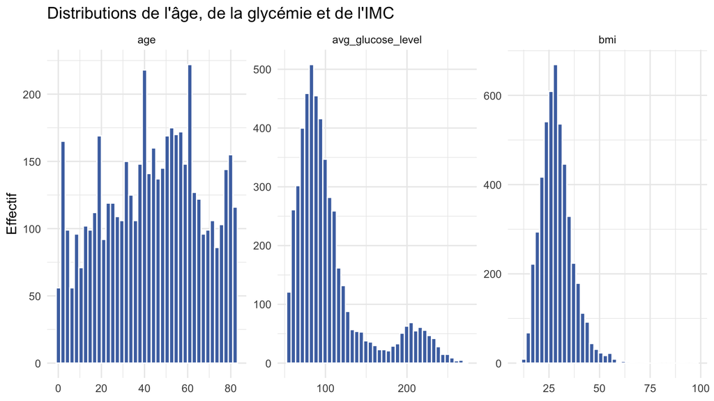

```r
# 分布图：看有没有奇怪的形状 / distributions : repérer les formes étranges
p0 <- df %>%
  select(age, avg_glucose_level, bmi) %>%
  pivot_longer(everything(), names_to = "variable", values_to = "valeur") %>%
  filter(!is.na(valeur)) %>%
  ggplot(aes(valeur)) +
  geom_histogram(bins = 40, fill = "#4C72B0", colour = "white") +
  facet_wrap(~ variable, scales = "free") +
  labs(x = NULL, y = "Effectif", title = "Distributions de l'âge, de la glycémie et de l'IMC")
p0
```

```r
ggsave(file.path(fig_dir, "fig0_distributions.png"), p0, width = 10, height = 3.5, dpi = 150)
```

### ✍️ 你来练习 / À vous de jouer

1. **中文**：`avg_glucose_level` 的分布有两个「峰」，你觉得可能是什么原因？（混合人群？糖尿病？测量方式？） **Français** : la glycémie présente deux « bosses ». Explications possibles ? (population mixte ? diabète ? mode de mesure ?)
2. **中文**：BMI 缺失者平均年龄更大（约 52 岁 vs 43 岁）。这会如何影响上面的结论？ **Français** : les IMC manquants sont plus âgés (~52 vs 43 ans). Comment cela influence-t-il la conclusion ?

# Étape 3 — Population d’analyse / 第 3 步：确定分析人群与变量处理

**中文**：每个清洗决定都要**记录理由**（见最后的「决策日志」）。

| 决定 | 理由 |
| --- | --- |
| 剔除 `gender = Other`（1 行） | 单行无法估计任何量 |
| **主分析仅限 ≥18 岁成人** | 婚姻、职业、吸烟对儿童无意义；儿童仅 2 例中风 |
| BMI 缺失：主分析用「完整案例」+ **敏感性分析**对比 4 种处理 | 缺失很可能非随机，任何单一方法都可能有偏 |
| 年龄、BMI、血糖分组 | 便于解释；代价是损失信息，因此同时保留连续版本 |

**Français** : chaque décision de nettoyage doit être **justifiée et tracée** (journal de décisions en fin de document).

| Décision | Justification |
| --- | --- |
| Exclure `gender = Other` (1 ligne) | Une ligne ne permet aucune estimation |
| **Analyse principale : adultes ≥ 18 ans** | Mariage, emploi, tabac n’ont pas de sens chez l’enfant ; 2 AVC seulement < 18 ans |
| IMC manquant : « cas complets » + **analyse de sensibilité** (4 méthodes) | Manque probablement non aléatoire → aucune méthode unique n’est sûre |
| Regroupements d’âge, IMC, glycémie | Faciles à interpréter ; perte d’information → on garde aussi les versions continues |

```r
bmi_labels <- c("Insuffisant (<18.5)", "Normal (18.5-24.9)", "Surpoids (25-29.9)", "Obesite (>=30)")

df <- df %>%
  filter(gender != "Other") %>%                      # (1) 剔除 Other / exclure Other
  mutate(
    # (2) 年龄分组；right = FALSE 表示区间 [左, 右) / groupes d'âge ; right = FALSE → [a, b[
    age_group = cut(age, breaks = c(0, 18, 30, 40, 50, 60, 70, 80, 200), right = FALSE,
                    labels = c("<18", "18-29", "30-39", "40-49", "50-59", "60-69", "70-79", "80+")),
    # (3) 分层分析用的三层年龄 / trois strates d'âge pour l'analyse stratifiée
    age_stratum = cut(age, breaks = c(0, 18, 50, 65, 200), right = FALSE,
                      labels = c("<18", "18-49", "50-64", "65+")),
    # (4) BMI 分类（WHO 成人标准）；缺失单独成类 / catégories d'IMC (OMS) ; manquants = catégorie à part
    bmi_cat = cut(bmi, breaks = c(0, 18.5, 25, 30, 200), right = FALSE, labels = bmi_labels),
    bmi_cat = factor(ifelse(is.na(bmi), "Manquant", as.character(bmi_cat)),
                     levels = c(bmi_labels, "Manquant")),
    # (5) 血糖分组：仅参考切点（测量方式未说明）/ glycémie : seuils indicatifs
    glucose_cat = cut(avg_glucose_level, breaks = c(0, 100, 140, 200, 1000), right = FALSE,
                      labels = c("<100", "100-139", "140-199", ">=200")),
    # (6) 设置因子水平 —— 第一个水平就是回归里的「参照组」！
    #     niveaux des facteurs — le 1er niveau est la RÉFÉRENCE dans la régression !
    gender         = factor(gender, levels = c("Female", "Male")),
    ever_married   = factor(ever_married, levels = c("No", "Yes")),
    Residence_type = factor(Residence_type, levels = c("Rural", "Urban")),
    smoking_status = factor(smoking_status,
                            levels = c("never smoked", "formerly smoked", "smokes", "Unknown")),
    work_type      = factor(work_type)
  )

adults <- df %>% filter(age >= 18)    # 主分析人群 / population principale

cat(sprintf("全部（剔除 Other 后）/ Ensemble : %d 人，AVC : %d\n", nrow(df), sum(df$stroke)))
```

```
## 全部（剔除 Other 后）/ Ensemble : 5109 人，AVC : 249
```

```r
cat(sprintf("成人 / Adultes >=18 : %d 人，AVC : %d（%.2f %%）\n",
            nrow(adults), sum(adults$stroke), mean(adults$stroke) * 100))
```

```
## 成人 / Adultes >=18 : 4253 人，AVC : 247（5.81 %）
```

```r
kt(count(adults, bmi_cat), 0)
```

| bmi_cat | n |
| --- | --- |
| Insuffisant (<18.5) | 38 |
| Normal (18.5-24.9) | 864 |
| Surpoids (25-29.9) | 1319 |
| Obesite (>=30) | 1851 |
| Manquant | 181 |

# Étape 4 — Tableau 1 / 第 4 步：「表 1」中风组 vs 非中风组

**中文** - **连续变量**（年龄、血糖、BMI）分布偏斜 → **中位数 [四分位距]**，检验用 **Mann-Whitney**（R 中是 `wilcox.test`）。 - **分类变量** → **n (%)**（占该组的百分比），检验用**卡方检验** `chisq.test`。

**Français** - **Variables continues** → **médiane [écart interquartile]**, test de **Mann-Whitney** (`wilcox.test` en R). - **Variables catégorielles** → **n (%)** (pourcentage *dans la colonne*), test du **khi-deux** `chisq.test`.

> ⚠️ **中文**：p 值 ≠ 重要性。样本大时，很小的差异也可能「显著」。 **Français** : p-valeur ≠ importance ; sur un grand échantillon de petites différences peuvent être « significatives ».

```r
table1 <- function(data, cont_vars, cat_vars, group = "stroke") {
  # data      : 数据框 / data.frame
  # cont_vars : 连续变量名 / noms des variables continues
  # cat_vars  : 分类变量名 / noms des variables catégorielles
  g0 <- data[data[[group]] == 0, ]      # 非中风 / sans AVC
  g1 <- data[data[[group]] == 1, ]      # 中风 / avec AVC
  rows <- list()
  q <- function(x) sprintf("%.1f [%.1f–%.1f]", median(x), quantile(x, .25), quantile(x, .75))

  # --- 连续变量：中位数 [Q1–Q3] + Mann-Whitney ---
  for (v in cont_vars) {
    a <- g0[[v]]; a <- a[!is.na(a)]
    b <- g1[[v]]; b <- b[!is.na(b)]
    p <- suppressWarnings(wilcox.test(a, b)$p.value)    # 有并列值时会有警告，可忽略 / avertissement (ex æquo) ignorable
    rows[[length(rows) + 1]] <- data.frame(Variable = v, Modalite = "mediane [Q1-Q3]",
                                           A = q(a), B = q(b), p = fmt_p(p), stringsAsFactors = FALSE)
  }

  # --- 分类变量：n (%) + 卡方 ---
  for (v in cat_vars) {
    ct <- table(data[[v]], data[[group]])              # 行 = 类别，列 = "0","1" / lignes = modalités, colonnes = "0","1"
    ct <- ct[rowSums(ct) > 0, , drop = FALSE]          # 去掉空行 / retirer les lignes vides
    p  <- suppressWarnings(chisq.test(ct)$p.value)
    for (i in seq_len(nrow(ct))) {
      rows[[length(rows) + 1]] <- data.frame(
        Variable = ifelse(i == 1, v, ""), Modalite = rownames(ct)[i],
        A = sprintf("%d (%.1f %%)", ct[i, "0"], ct[i, "0"] / sum(ct[, "0"]) * 100),
        B = sprintf("%d (%.1f %%)", ct[i, "1"], ct[i, "1"] / sum(ct[, "1"]) * 100),
        p = ifelse(i == 1, fmt_p(p), ""), stringsAsFactors = FALSE)
    }
  }
  out <- bind_rows(rows)
  names(out) <- c("Variable", "Modalité",
                  paste0("Sans AVC (n=", nrow(g0), ")"), paste0("AVC (n=", nrow(g1), ")"), "p")
  out
}

t1 <- table1(adults,
             cont_vars = c("age", "avg_glucose_level", "bmi"),
             cat_vars  = c("gender", "hypertension", "heart_disease", "ever_married",
                           "work_type", "Residence_type", "smoking_status", "bmi_cat", "glucose_cat"))
kt(t1)
```

| Variable | Modalité | Sans AVC (n=4006) | AVC (n=247) | p |
| --- | --- | --- | --- | --- |
| age | mediane [Q1-Q3] | 49.0 [35.0–62.0] | 71.0 [59.0–78.0] | <0.001 |
| avg_glucose_level | mediane [Q1-Q3] | 91.9 [77.3–114.3] | 105.9 [80.3–196.8] | <0.001 |
| bmi | mediane [Q1-Q3] | 29.2 [25.4–34.2] | 29.6 [26.4–33.7] | 0.506 |
| gender | Female | 2437 (60.8 %) | 139 (56.3 %) | 0.175 |
|  | Male | 1569 (39.2 %) | 108 (43.7 %) |  |
| hypertension | 0 | 3575 (89.2 %) | 181 (73.3 %) | <0.001 |
|  | 1 | 431 (10.8 %) | 66 (26.7 %) |  |
| heart_disease | 0 | 3778 (94.3 %) | 200 (81.0 %) | <0.001 |
|  | 1 | 228 (5.7 %) | 47 (19.0 %) |  |
| ever_married | No | 873 (21.8 %) | 27 (10.9 %) | <0.001 |
|  | Yes | 3133 (78.2 %) | 220 (89.1 %) |  |
| work_type | Govt_job | 618 (15.4 %) | 33 (13.4 %) | 0.023 |
|  | Never_worked | 5 (0.1 %) | 0 (0.0 %) |  |
|  | Private | 2641 (65.9 %) | 149 (60.3 %) |  |
|  | Self-employed | 742 (18.5 %) | 65 (26.3 %) |  |
| Residence_type | Rural | 1971 (49.2 %) | 113 (45.7 %) | 0.323 |
|  | Urban | 2035 (50.8 %) | 134 (54.3 %) |  |
| smoking_status | never smoked | 1662 (41.5 %) | 90 (36.4 %) | 0.013 |
|  | formerly smoked | 789 (19.7 %) | 70 (28.3 %) |  |
|  | smokes | 738 (18.4 %) | 42 (17.0 %) |  |
|  | Unknown | 817 (20.4 %) | 45 (18.2 %) |  |
| bmi_cat | Insuffisant (<18.5) | 37 (0.9 %) | 1 (0.4 %) | <0.001 |
|  | Normal (18.5-24.9) | 829 (20.7 %) | 35 (14.2 %) |  |
|  | Surpoids (25-29.9) | 1244 (31.1 %) | 75 (30.4 %) |  |
|  | Obesite (>=30) | 1754 (43.8 %) | 97 (39.3 %) |  |
|  | Manquant | 142 (3.5 %) | 39 (15.8 %) |  |
| glucose_cat | <100 | 2453 (61.2 %) | 110 (44.5 %) | <0.001 |
|  | 100-139 | 876 (21.9 %) | 44 (17.8 %) |  |
|  | 140-199 | 306 (7.6 %) | 37 (15.0 %) |  |
|  | >=200 | 371 (9.3 %) | 56 (22.7 %) |  |

### ✍️ 你来练习 / À vous de jouer

**中文**：表 1 中两组**差别最大**的 3 个变量是什么？它们是「危险因素」还是「年龄的影子」？（下一步会告诉你为什么这很重要。） **Français** : quelles 3 variables diffèrent le plus ? Vrais « facteurs de risque » ou « ombre de l’âge » ?

# Étape 5 — Analyse bivariée / 第 5 步：比较「率」，不是「数量」

**中文** - 「中风者里吸烟的有多少」≠「吸烟者里中风的有多少」——**分母不同**！我们要的是后者：**每个类别中的中风率**。 - 每个率配上 **n** 与 **95% 置信区间（Wilson 法）**：样本越小，区间越宽。 - R 小贴士：`prop.test(k, n, correct = FALSE)` 给出的正是 Wilson 区间。

**Français** - « Parmi les AVC, combien fument ? » ≠ « Parmi les fumeurs, combien ont eu un AVC ? » — **le dénominateur diffère**. On veut le second : le **taux d’AVC par catégorie**. - Chaque taux avec **n** et **IC à 95 % (Wilson)**. - Astuce R : `prop.test(k, n, correct = FALSE)` renvoie précisément l’intervalle de Wilson.

## 5.1 通用函数 / Fonctions utilitaires

```r
# Wilson 置信区间 / IC de Wilson
wilson_ci <- function(k, n) {
  if (n == 0) return(c(NA_real_, NA_real_))
  as.numeric(suppressWarnings(prop.test(k, n, correct = FALSE)$conf.int))
}

# 给表格加上「率」与置信区间（要求有 evenements 和 n 两列）
# ajoute taux et IC (le tableau doit contenir les colonnes evenements et n)
add_rate <- function(d) {
  ci <- t(mapply(wilson_ci, d$evenements, d$n))     # 每行一个 (下限, 上限) / une ligne (bas, haut) par modalité
  d$taux_pct  <- d$evenements / d$n * 100
  d$ic95_bas  <- ci[, 1] * 100
  d$ic95_haut <- ci[, 2] * 100
  d
}

# 每个类别的：样本数、事件数、中风率、区间 / par modalité : effectif, événements, taux, IC
rate_table <- function(data, var, order = NULL) {
  out <- data %>%
    group_by(across(all_of(var))) %>%
    summarise(n = n(), evenements = sum(stroke), .groups = "drop")
  out$modalite <- as.character(out[[var]])
  out <- out[, c("modalite", "n", "evenements")]
  if (!is.null(order)) out <- out[match(order, out$modalite), ]   # 指定显示顺序 / imposer l'ordre
  add_rate(out)
}

# 卡方检验 p 值（期望频数<5 时不可靠，应改用 Fisher）/ p-valeur du khi-deux (peu fiable si effectifs attendus < 5)
chi2_p <- function(data, var) {
  ct <- table(data[[var]], data$stroke)
  ct <- ct[rowSums(ct) > 0, , drop = FALSE]
  suppressWarnings(chisq.test(ct)$p.value)
}
```

## 5.2 各因素的中风率（成人）/ Taux d’AVC par facteur (adultes)

```r
factors <- c("hypertension", "heart_disease", "ever_married", "gender", "Residence_type",
             "smoking_status", "bmi_cat", "glucose_cat", "work_type")

for (v in factors) {
  cat("\n\n#### ", v, " — khi-deux p = ", fmt_p(chi2_p(adults, v)), "\n\n", sep = "")
  cat(kt(rate_table(adults, v)), sep = "\n")
  cat("\n")
}
```

#### hypertension — khi-deux p = <0.001

| modalite | n | evenements | taux_pct | ic95_bas | ic95_haut |
| --- | --- | --- | --- | --- | --- |
| 0 | 3756 | 181 | 4.82 | 4.18 | 5.55 |
| 1 | 497 | 66 | 13.28 | 10.58 | 16.55 |

#### heart_disease — khi-deux p = <0.001

| modalite | n | evenements | taux_pct | ic95_bas | ic95_haut |
| --- | --- | --- | --- | --- | --- |
| 0 | 3978 | 200 | 5.03 | 4.39 | 5.75 |
| 1 | 275 | 47 | 17.09 | 13.10 | 21.99 |

#### ever_married — khi-deux p = <0.001

| modalite | n | evenements | taux_pct | ic95_bas | ic95_haut |
| --- | --- | --- | --- | --- | --- |
| No | 900 | 27 | 3.00 | 2.07 | 4.33 |
| Yes | 3353 | 220 | 6.56 | 5.77 | 7.45 |

#### gender — khi-deux p = 0.175

| modalite | n | evenements | taux_pct | ic95_bas | ic95_haut |
| --- | --- | --- | --- | --- | --- |
| Female | 2576 | 139 | 5.40 | 4.59 | 6.34 |
| Male | 1677 | 108 | 6.44 | 5.36 | 7.72 |

#### Residence_type — khi-deux p = 0.323

| modalite | n | evenements | taux_pct | ic95_bas | ic95_haut |
| --- | --- | --- | --- | --- | --- |
| Rural | 2084 | 113 | 5.42 | 4.53 | 6.48 |
| Urban | 2169 | 134 | 6.18 | 5.24 | 7.27 |

#### smoking_status — khi-deux p = 0.013

| modalite | n | evenements | taux_pct | ic95_bas | ic95_haut |
| --- | --- | --- | --- | --- | --- |
| never smoked | 1752 | 90 | 5.14 | 4.20 | 6.27 |
| formerly smoked | 859 | 70 | 8.15 | 6.50 | 10.17 |
| smokes | 780 | 42 | 5.38 | 4.01 | 7.20 |
| Unknown | 862 | 45 | 5.22 | 3.92 | 6.91 |

#### bmi_cat — khi-deux p = <0.001

| modalite | n | evenements | taux_pct | ic95_bas | ic95_haut |
| --- | --- | --- | --- | --- | --- |
| Insuffisant (<18.5) | 38 | 1 | 2.63 | 0.47 | 13.49 |
| Normal (18.5-24.9) | 864 | 35 | 4.05 | 2.93 | 5.58 |
| Surpoids (25-29.9) | 1319 | 75 | 5.69 | 4.56 | 7.07 |
| Obesite (>=30) | 1851 | 97 | 5.24 | 4.31 | 6.35 |
| Manquant | 181 | 39 | 21.55 | 16.18 | 28.09 |

#### glucose_cat — khi-deux p = <0.001

| modalite | n | evenements | taux_pct | ic95_bas | ic95_haut |
| --- | --- | --- | --- | --- | --- |
| <100 | 2563 | 110 | 4.29 | 3.57 | 5.15 |
| 100-139 | 920 | 44 | 4.78 | 3.58 | 6.36 |
| 140-199 | 343 | 37 | 10.79 | 7.93 | 14.51 |
| >=200 | 427 | 56 | 13.11 | 10.24 | 16.65 |

#### work_type — khi-deux p = 0.023

| modalite | n | evenements | taux_pct | ic95_bas | ic95_haut |
| --- | --- | --- | --- | --- | --- |
| Govt_job | 651 | 33 | 5.07 | 3.63 | 7.03 |
| Never_worked | 5 | 0 | 0.00 | 0.00 | 43.45 |
| Private | 2790 | 149 | 5.34 | 4.57 | 6.24 |
| Self-employed | 807 | 65 | 8.05 | 6.37 | 10.14 |

## 5.3 图 1：各年龄段中风率 / Figure 1 : taux d’AVC par tranche d’âge

**中文**：本项目最重要的一张图。注意这里用**全部人群**（含 <18 岁）。 **Français** : le graphique clé du projet. On utilise ici **toute la population** (mineurs inclus).

```r
age_rates <- rate_table(df, "age_group")
kt(age_rates)
```

| modalite | n | evenements | taux_pct | ic95_bas | ic95_haut |
| --- | --- | --- | --- | --- | --- |
| <18 | 856 | 2 | 0.23 | 0.06 | 0.85 |
| 18-29 | 658 | 0 | 0.00 | 0.00 | 0.58 |
| 30-39 | 655 | 6 | 0.92 | 0.42 | 1.98 |
| 40-49 | 730 | 12 | 1.64 | 0.94 | 2.85 |
| 50-59 | 834 | 48 | 5.76 | 4.37 | 7.55 |
| 60-69 | 621 | 47 | 7.57 | 5.74 | 9.92 |
| 70-79 | 569 | 94 | 16.52 | 13.70 | 19.79 |
| 80+ | 186 | 40 | 21.51 | 16.21 | 27.95 |

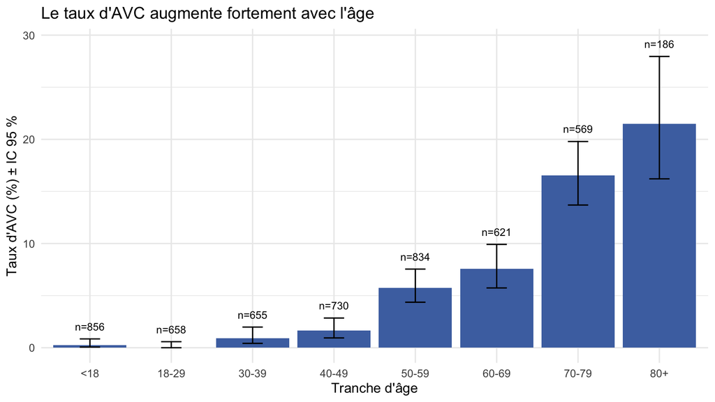

```r
p1 <- ggplot(age_rates, aes(x = factor(modalite, levels = modalite), y = taux_pct)) +
  geom_col(fill = "#4C72B0") +
  geom_errorbar(aes(ymin = ic95_bas, ymax = ic95_haut), width = 0.25) +
  geom_text(aes(y = ic95_haut + 1.2, label = paste0("n=", n)), size = 3) +   # 标注样本量 / annoter n
  labs(x = "Tranche d'âge", y = "Taux d'AVC (%) ± IC 95 %",
       title = "Le taux d'AVC augmente fortement avec l'âge")                # 标题写结论 / titre = conclusion
p1
```

```r
ggsave(file.path(fig_dir, "fig1_taux_par_age.png"), p1, width = 8, height = 4, dpi = 150)
```

## 5.4 图 2：主要因素（小多图）/ Figure 2 : petits multiples

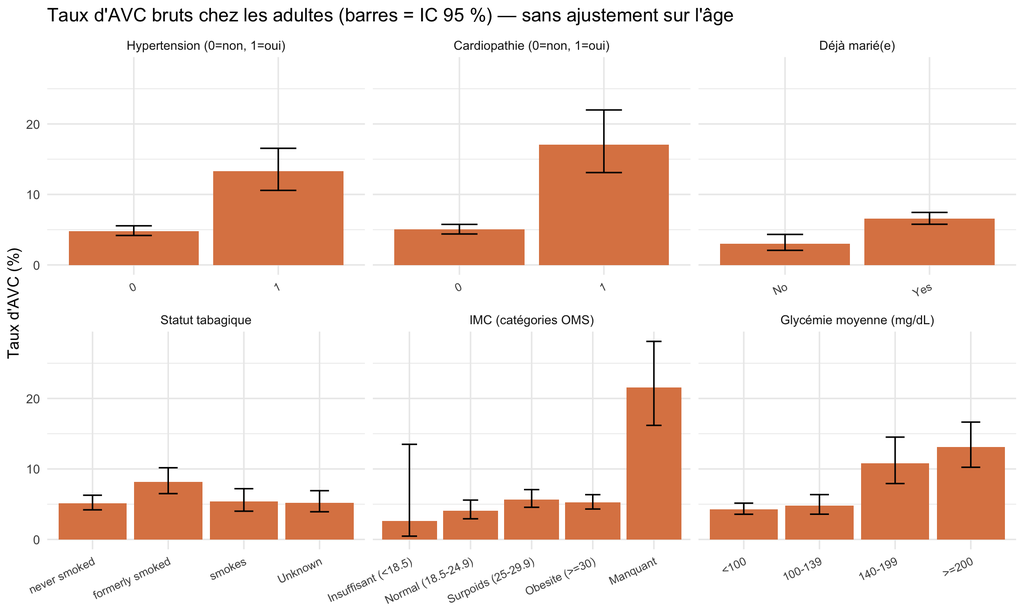

```r
mk <- function(var, titre) rate_table(adults, var) %>% mutate(facteur = titre)

fig2_data <- bind_rows(
  mk("hypertension",   "Hypertension (0=non, 1=oui)"),
  mk("heart_disease",  "Cardiopathie (0=non, 1=oui)"),
  mk("ever_married",   "Déjà marié(e)"),
  mk("smoking_status", "Statut tabagique"),
  mk("bmi_cat",        "IMC (catégories OMS)"),
  mk("glucose_cat",    "Glycémie moyenne (mg/dL)")
) %>%
  mutate(facteur   = factor(facteur, levels = unique(facteur)),
         modalite  = factor(modalite, levels = unique(modalite)))

p2 <- ggplot(fig2_data, aes(x = modalite, y = taux_pct)) +
  geom_col(fill = "#DD8452") +
  geom_errorbar(aes(ymin = ic95_bas, ymax = ic95_haut), width = 0.25) +
  facet_wrap(~ facteur, scales = "free_x", ncol = 3) +
  labs(x = NULL, y = "Taux d'AVC (%)",
       title = "Taux d'AVC bruts chez les adultes (barres = IC 95 %) — sans ajustement sur l'âge") +
  theme(axis.text.x = element_text(angle = 25, hjust = 1, size = 8))
p2
```

```r
ggsave(file.path(fig_dir, "fig2_taux_par_facteur.png"), p2, width = 11, height = 6.5, dpi = 150)
```

### ✍️ 你来练习 / À vous de jouer

**中文**：图 2 中「已婚」的中风率明显更高。**继续往下看之前**，写下 1 个可被数据检验的解释（不是「结婚使人中风」）。 **Français** : dans la Figure 2, le taux d’AVC des mariés est nettement plus élevé. **Avant de continuer**, notez une explication **testable** (pas « le mariage provoque l’AVC »).

# Étape 6 — Facteurs de confusion / 第 6 步：混杂因素——分层与调整（项目灵魂）

**中文**：**混杂因素**= 同时与「暴露」（如婚姻）和「结局」（中风）相关、且不在因果链上的第三个变量。这份数据里，**年龄**就是主要混杂因素。 **Français** : un **facteur de confusion** est une variable liée à la fois à l’exposition et à l’issue, hors de la chaîne causale. Ici, c’est **l’âge**.

## 6.1 证据一：年龄与其他变量高度相关 / Preuve 1 : l’âge est lié aux autres variables

```r
# 用全部人群展示这个现象 / toute la population pour montrer le phénomène
for (v in c("ever_married", "hypertension", "heart_disease", "smoking_status", "work_type")) {
  cat("\n\n**年龄均值 / Âge moyen selon", v, "**\n\n")
  df %>% group_by(across(all_of(v))) %>%
    summarise(n = n(), age_moyen = mean(age)) %>%
    kt(1) %>% cat(sep = "\n")
}
```

**年龄均值 / Âge moyen selon ever_married**

| ever_married | n | age_moyen |
| --- | --- | --- |
| No | 1756 | 22.0 |
| Yes | 3353 | 54.3 |

**年龄均值 / Âge moyen selon hypertension**

| hypertension | n | age_moyen |
| --- | --- | --- |
| 0 | 4611 | 41.2 |
| 1 | 498 | 62.2 |

**年龄均值 / Âge moyen selon heart_disease**

| heart_disease | n | age_moyen |
| --- | --- | --- |
| 0 | 4833 | 41.8 |
| 1 | 276 | 68.2 |

**年龄均值 / Âge moyen selon smoking_status**

| smoking_status | n | age_moyen |
| --- | --- | --- |
| never smoked | 1892 | 46.7 |
| formerly smoked | 884 | 55.0 |
| smokes | 789 | 47.1 |
| Unknown | 1544 | 30.2 |

**年龄均值 / Âge moyen selon work_type**

| work_type | n | age_moyen |
| --- | --- | --- |
| children | 687 | 6.8 |
| Govt_job | 657 | 50.9 |
| Never_worked | 22 | 16.2 |
| Private | 2924 | 45.5 |
| Self-employed | 819 | 60.2 |

```r
cat("\n\n➜ 已婚者比未婚者平均大 30 多岁；有高血压/心脏病者也明显更老 → 年龄同时与「暴露」和「中风」相关 = 混杂因素的定义。\n\n")
```

➜ 已婚者比未婚者平均大 30 多岁；有高血压/心脏病者也明显更老 → 年龄同时与「暴露」和「中风」相关 = 混杂因素的定义。

```r
cat("➜ Les mariés ont 30 ans de plus en moyenne ; idem hypertension / cardiopathie → l'âge est lié à l'exposition ET à l'AVC = définition d'un facteur de confusion.\n")
```

➜ Les mariés ont 30 ans de plus en moyenne ; idem hypertension / cardiopathie → l’âge est lié à l’exposition ET à l’AVC = définition d’un facteur de confusion.

## 6.2 辅助函数 / Fonctions : OR brut, Mantel-Haenszel

**中文**：R 自带 `mantelhaen.test()`，直接给出 Mantel-Haenszel 合并 OR 与置信区间（把每一层的 OR 加权合并 = 已「控制」分层变量）。 **Français** : R fournit `mantelhaen.test()` : OR commun de Mantel-Haenszel et son IC (les OR de chaque strate sont combinés → la variable de stratification est « contrôlée »).

```r
# 构造 2x2 表：行 = 暴露/未暴露，列 = 中风/未中风
# tableau 2x2 : lignes = exposé/non exposé, colonnes = AVC/pas d'AVC
two_by_two <- function(sub, exposure, exposed_value) {
  e <- sub[[exposure]] == exposed_value
  s <- sub$stroke == 1
  matrix(c(sum(e & s), sum(!e & s), sum(e & !s), sum(!e & !s)), nrow = 2,
         dimnames = list(c("expose", "non_expose"), c("AVC", "pas_AVC")))
}

# 粗 OR + Woolf 置信区间 / OR brut + IC de Woolf
crude_or <- function(tab) {
  a <- tab[1, 1]; b <- tab[1, 2]; c <- tab[2, 1]; d <- tab[2, 2]
  or <- (a * d) / (b * c)
  se <- sqrt(1 / a + 1 / b + 1 / c + 1 / d)
  c(OR = or, IC_bas = exp(log(or) - 1.96 * se), IC_haut = exp(log(or) + 1.96 * se))
}
```

## 6.3 经典例子：已婚 vs 未婚 / Exemple classique : marié vs non marié (adultes)

> **中文**：分段边界为 [a, b)，所以数字与我在对话里手算的略有差别，结论一致。 **Français** : bornes des strates [a, b[ : chiffres un peu différents de mon calcul manuel, conclusion identique.

```r
# ① 粗率 / taux bruts
brut_tab <- adults %>%
  group_by(ever_married) %>%
  summarise(n = n(), evenements = sum(stroke), taux_pct = mean(stroke) * 100)
cat("① 粗率（未控制年龄）/ Taux bruts (sans contrôle de l'âge)\n")
```

```
## ① 粗率（未控制年龄）/ Taux bruts (sans contrôle de l'âge)
```

```r
kt(brut_tab)
```

| ever_married | n | evenements | taux_pct |
| --- | --- | --- | --- |
| No | 900 | 27 | 3.00 |
| Yes | 3353 | 220 | 6.56 |

```r
# ② 分层后：同龄人内比较 / après stratification : à âge comparable
strat_tab <- adults %>%
  group_by(age_stratum, ever_married) %>%
  summarise(n = n(), evenements = sum(stroke), taux_pct = mean(stroke) * 100)
cat("\n② 分层后 / Après stratification\n")
```

```
##
## ② 分层后 / Après stratification
```

```r
kt(strat_tab)
```

| age_stratum | ever_married | n | evenements | taux_pct |
| --- | --- | --- | --- | --- |
| 18-49 | No | 728 | 3 | 0.41 |
| 18-49 | Yes | 1315 | 15 | 1.14 |
| 50-64 | No | 84 | 4 | 4.76 |
| 50-64 | Yes | 1099 | 66 | 6.01 |
| 65+ | No | 88 | 20 | 22.73 |
| 65+ | Yes | 939 | 139 | 14.80 |

```r
# ③ 粗 OR vs Mantel-Haenszel 调整 OR / OR brut vs OR ajusté (MH)
strata <- c("18-49", "50-64", "65+")
tables <- lapply(strata, function(s) two_by_two(adults[adults$age_stratum == s, ], "ever_married", "Yes"))
arr    <- array(unlist(tables), dim = c(2, 2, length(tables)))   # 2 x 2 x K 三维数组 / tableau 2 x 2 x K
mh     <- mantelhaen.test(arr)
or_brut_mar <- crude_or(two_by_two(adults, "ever_married", "Yes"))

cat(sprintf("\n③ OR brut / 粗 OR               = %.2f  [IC 95 %% %.2f–%.2f]\n",
            or_brut_mar["OR"], or_brut_mar["IC_bas"], or_brut_mar["IC_haut"]))
```

```
##
## ③ OR brut / 粗 OR               = 2.27  [IC 95 % 1.51–3.41]
```

```r
cat(sprintf("   OR ajusté sur l'âge (MH) / 年龄调整 = %.2f  [IC 95 %% %.2f–%.2f]\n",
            mh$estimate, mh$conf.int[1], mh$conf.int[2]))
```

```
##    OR ajusté sur l'âge (MH) / 年龄调整 = 0.91  [IC 95 % 0.59–1.40]
```

```r
cat("\n➜ 调整年龄后，OR 大幅向 1 靠拢——婚姻的「效应」大部分是年龄的影子。\n")
```

```
##
## ➜ 调整年龄后，OR 大幅向 1 靠拢——婚姻的「效应」大部分是年龄的影子。
```

```r
cat("➜ Après ajustement sur l'âge, l'OR se rapproche fortement de 1 — l'« effet » du mariage est surtout l'ombre de l'âge.\n")
```

```
## ➜ Après ajustement sur l'âge, l'OR se rapproche fortement de 1 — l'« effet » du mariage est surtout l'ombre de l'âge.
```

```r
cat("➜ ⚠ 65+ 未婚者样本很小，该层的率不稳定 / strate 65+ non mariés : effectif faible, taux instable.\n")
```

```
## ➜ ⚠ 65+ 未婚者样本很小，该层的率不稳定 / strate 65+ non mariés : effectif faible, taux instable.
```

## 6.4 图 3：粗看 vs 分层后 / Figure 3 : brut vs stratifié

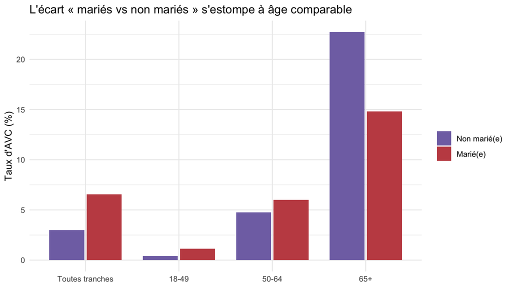

```r
fig3_data <- bind_rows(
  brut_tab %>% mutate(strate = "Toutes tranches"),
  strat_tab %>% ungroup() %>% mutate(strate = as.character(age_stratum)) %>% select(-age_stratum)
) %>%
  mutate(strate = factor(strate, levels = c("Toutes tranches", "18-49", "50-64", "65+")))

p3 <- ggplot(fig3_data, aes(x = strate, y = taux_pct, fill = ever_married)) +
  geom_col(position = position_dodge(width = 0.8), width = 0.75) +
  scale_fill_manual(values = c(Yes = "#C44E52", No = "#8172B2"),
                    labels = c(Yes = "Marié(e)", No = "Non marié(e)"), name = NULL) +
  labs(x = NULL, y = "Taux d'AVC (%)",
       title = "L'écart « mariés vs non mariés » s'estompe à âge comparable")
p3
```

```r
ggsave(file.path(fig_dir, "fig3_confusion_mariage.png"), p3, width = 8, height = 4.2, dpi = 150)
```

## 6.5 反直觉现象：吸烟 / Un résultat contre-intuitif : le tabac

**中文**：为什么「曾经吸烟」的中风率比「正在吸烟」还高？原则：遇到反常结果，**先怀疑数据与混杂，而不是怀疑医学常识**。 **Français** : pourquoi les ex-fumeurs ont-ils un taux plus élevé que les fumeurs ? Principe : devant un résultat étrange, **douter d’abord des données et de la confusion**, pas de la médecine.

```r
cat("**① 粗率 / Taux bruts (adultes)**\n\n")
```

**① 粗率 / Taux bruts (adultes)**

```r
cat(kt(rate_table(adults, "smoking_status")), sep = "\n")
```

| modalite | n | evenements | taux_pct | ic95_bas | ic95_haut |
| --- | --- | --- | --- | --- | --- |
| never smoked | 1752 | 90 | 5.14 | 4.20 | 6.27 |
| formerly smoked | 859 | 70 | 8.15 | 6.50 | 10.17 |
| smokes | 780 | 42 | 5.38 | 4.01 | 7.20 |
| Unknown | 862 | 45 | 5.22 | 3.92 | 6.91 |

```r
cat("\n\n**② 各组平均年龄（假设 A：前吸烟者更老）/ Âge moyen (hypothèse A : ex-fumeurs plus âgés)**\n\n")
```

**② 各组平均年龄（假设 A：前吸烟者更老）/ Âge moyen (hypothèse A : ex-fumeurs plus âgés)**

```r
adults %>% group_by(smoking_status) %>% summarise(age_moyen = mean(age)) %>% kt(1) %>% cat(sep = "\n")
```

| smoking_status | age_moyen |
| --- | --- |
| never smoked | 49.3 |
| formerly smoked | 56.2 |
| smokes | 47.5 |
| Unknown | 48.5 |

```r
cat("\n\n**③ 分年龄层的中风率 (%) / Taux (%) par strate d'âge**\n\n")
```

**③ 分年龄层的中风率 (%) / Taux (%) par strate d’âge**

```r
adults %>%
  group_by(age_stratum, smoking_status) %>%
  summarise(taux_pct = mean(stroke) * 100) %>%
  pivot_wider(names_from = smoking_status, values_from = taux_pct) %>%
  kt(2) %>% cat(sep = "\n")
```

| age_stratum | never smoked | formerly smoked | smokes | Unknown |
| --- | --- | --- | --- | --- |
| 18-49 | 0.79 | 1.43 | 1.18 | 0.44 |
| 50-64 | 3.72 | 6.41 | 8.89 | 6.82 |
| 65+ | 16.22 | 16.05 | 13.08 | 14.66 |

```r
cat("\n\n**④ 各层样本量 / Effectifs par strate**\n\n")
```

**④ 各层样本量 / Effectifs par strate**

```r
adults %>%
  count(age_stratum, smoking_status) %>%
  pivot_wider(names_from = smoking_status, values_from = n) %>%
  kt(0) %>% cat(sep = "\n")
```

| age_stratum | never smoked | formerly smoked | smokes | Unknown |
| --- | --- | --- | --- | --- |
| 18-49 | 888 | 279 | 425 | 451 |
| 50-64 | 457 | 281 | 225 | 220 |
| 65+ | 407 | 299 | 130 | 191 |

```r
cat("\n\n**可检验的假设 / Hypothèses testables**\n\n")
```

**可检验的假设 / Hypothèses testables**

```r
cat("- A. 年龄混杂：前吸烟者更老 / Confusion par l'âge : ex-fumeurs plus âgés\n")
```

- A. 年龄混杂：前吸烟者更老 / Confusion par l’âge : ex-fumeurs plus âgés

```r
cat("- B. 病后戒烟（反向因果）/ « Sick-quitter » : arrêt du tabac APRÈS un problème de santé (causalité inverse)\n")
```

- B. 病后戒烟（反向因果）/ « Sick-quitter » : arrêt du tabac APRÈS un problème de santé (causalité inverse)

```r
cat("- C. Unknown 组构成不同 / La catégorie Unknown a une composition différente\n\n")
```

- C. Unknown 组构成不同 / La catégorie Unknown a une composition différente

```r
cat("⚠ 本数据没有戒烟原因，B 无法直接验证——应写进局限性。\n\n")
```

⚠ 本数据没有戒烟原因，B 无法直接验证——应写进局限性。

```r
cat("⚠ Pas de raison d'arrêt dans les données : B n'est pas vérifiable directement → à noter dans les limites.\n")
```

⚠ Pas de raison d’arrêt dans les données : B n’est pas vérifiable directement → à noter dans les limites.

### ✍️ 你来练习 / À vous de jouer

**中文**：看表 ③：分年龄层后，「前吸烟」的优势是否消失？完全还是部分？哪一层样本太小、不能下结论？ **Français** : tableau ③ : après stratification, la surcote des ex-fumeurs disparaît-elle ? Totalement ou partiellement ? Quelle strate est trop petite ?

### 🧠 混杂因素 vs 中介变量 / Facteur de confusion vs variable médiatrice

**中文**：并不是「变量放得越多越好」。 - **混杂因素**（如年龄）：**应该**调整。 - **中介变量**：处在因果链**中间**。例如 `BMI → 高血压 → 中风`：研究 BMI 的作用时若又「调整高血压」，就把 BMI 通过高血压起作用的那部分**抹掉**了。 - 该不该调整，取决于**你的问题**。建议先在纸上画一张因果图（DAG）。

**Français** : ajouter des variables n’est pas toujours mieux. - **Facteur de confusion** (âge) : il **faut** ajuster. - **Variable médiatrice** : au **milieu** de la chaîne causale. Ex. `IMC → hypertension → AVC` : ajuster sur l’hypertension **supprime** la part de l’effet de l’IMC qui passe par elle. - Ajuster ou non dépend de **votre question**. Dessinez d’abord un graphe causal (DAG).

## 6.6 多因素逻辑回归 / Régression logistique multivariée

**中文** - **OR 解读**：OR = 2 表示该组「中风的 odds」是参照组的 2 倍；OR = 1 表示无关联。OR ≠ 风险比：事件罕见时接近，否则 OR 会夸大。 - R 里用 `glm(..., family = binomial)`；`confint.default()` 给 Wald 区间（`confint()` 给轮廓似然区间，略有不同）。 - **参照组**由因子的第一个水平决定（我们在第 3 步已设好）。

**Français** - **Lecture de l’OR** : OR = 2 → cotes d’AVC doublées vs la référence ; OR = 1 → pas d’association. OR ≠ risque relatif : proches si l’événement est rare, sinon l’OR exagère. - En R : `glm(..., family = binomial)` ; `confint.default()` donne l’IC de Wald (`confint()` : vraisemblance profilée, légèrement différent). - La **référence** est le 1er niveau du facteur (défini à l’étape 3).

```r
# 换成更有意义的单位 / unités plus parlantes
model_df <- adults %>%
  mutate(age10     = age / 10,                    # 每增加 10 岁 / par 10 ans
         glucose10 = avg_glucose_level / 10,      # 每增加 10 mg/dL / par 10 mg/dL
         bmi5      = bmi / 5)                     # 每增加 5 kg/m² / par 5 kg/m²

# 完整案例：粗 OR 与调整 OR 使用同一批人才可比
# cas complets : mêmes personnes pour brut et ajusté, pour être comparables
cc <- model_df %>% filter(!is.na(bmi))

adj_formula <- stroke ~ age10 + hypertension + heart_disease + glucose10 + bmi5 +
                        gender + ever_married + smoking_status + Residence_type

# 从 glm 结果提取 OR 表 / extraire le tableau d'OR d'un glm
or_table <- function(fit) {
  co <- coef(summary(fit))
  ci <- confint.default(fit)                       # Wald 区间 / IC de Wald
  tibble(terme = rownames(co), OR = exp(co[, "Estimate"]),
         ic95_bas = exp(ci[, 1]), ic95_haut = exp(ci[, 2]), p = co[, "Pr(>|z|)"]) %>%
    filter(terme != "(Intercept)")
}

# ① 调整 OR：所有变量一起 / OR ajustés : toutes les variables ensemble
fit_adj <- glm(adj_formula, data = cc, family = binomial)
adj_tbl <- or_table(fit_adj)

# ② 粗 OR：每个变量单独 / OR bruts : une variable à la fois
vars <- c("age10", "hypertension", "heart_disease", "glucose10", "bmi5",
          "gender", "ever_married", "smoking_status", "Residence_type")
crude_tbl <- bind_rows(lapply(vars, function(v) {
  or_table(glm(reformulate(v, response = "stroke"), data = cc, family = binomial))
}))

# 更易读的名称 / libellés lisibles
labels_map <- c(
  age10 = "âge (par 10 ans)", hypertension = "hypertension (oui vs non)",
  heart_disease = "cardiopathie (oui vs non)", glucose10 = "glycémie (par 10 mg/dL)",
  bmi5 = "IMC (par 5 kg/m²)", genderMale = "sexe : homme (réf. femme)",
  ever_marriedYes = "marié(e) : oui (réf. non)",
  `smoking_statusformerly smoked` = "tabac : ancien fumeur (réf. jamais)",
  smoking_statussmokes = "tabac : fumeur (réf. jamais)",
  smoking_statusUnknown = "tabac : Unknown (réf. jamais)",
  Residence_typeUrban = "résidence : urbaine (réf. rurale)")

compare_tbl <- adj_tbl %>%
  left_join(crude_tbl %>% select(terme, OR_brut = OR), by = "terme") %>%
  mutate(etiquette = unname(labels_map[terme]), p_txt = fmt_p(p)) %>%
  select(etiquette, OR_brut, OR_ajuste = OR, ic95_bas, ic95_haut, p = p_txt)

cat(sprintf("完整案例 / Cas complets : n = %d，中风 / AVC = %d\n", nobs(fit_adj), sum(fit_adj$y)))
```

```
## 完整案例 / Cas complets : n = 4072，中风 / AVC = 208
```

```r
kt(compare_tbl, 3)
```

| etiquette | OR_brut | OR_ajuste | ic95_bas | ic95_haut | p |
| --- | --- | --- | --- | --- | --- |
| âge (par 10 ans) | 2.111 | 1.998 | 1.770 | 2.254 | <0.001 |
| hypertension (oui vs non) | 3.611 | 1.677 | 1.191 | 2.361 | 0.003 |
| cardiopathie (oui vs non) | 4.316 | 1.443 | 0.963 | 2.163 | 0.076 |
| glycémie (par 10 mg/dL) | 1.105 | 1.049 | 1.023 | 1.076 | <0.001 |
| IMC (par 5 kg/m²) | 1.003 | 1.012 | 0.900 | 1.138 | 0.839 |
| sexe : homme (réf. femme) | 1.185 | 1.003 | 0.741 | 1.358 | 0.983 |
| marié(e) : oui (réf. non) | 2.370 | 0.895 | 0.552 | 1.450 | 0.652 |
| tabac : ancien fumeur (réf. jamais) | 1.463 | 1.057 | 0.730 | 1.529 | 0.770 |
| tabac : fumeur (réf. jamais) | 1.098 | 1.456 | 0.957 | 2.214 | 0.080 |
| tabac : Unknown (réf. jamais) | 0.689 | 0.804 | 0.509 | 1.271 | 0.350 |
| résidence : urbaine (réf. rurale) | 1.064 | 1.021 | 0.760 | 1.370 | 0.892 |

## 6.7 图 4：森林图 / Figure 4 : forest plot

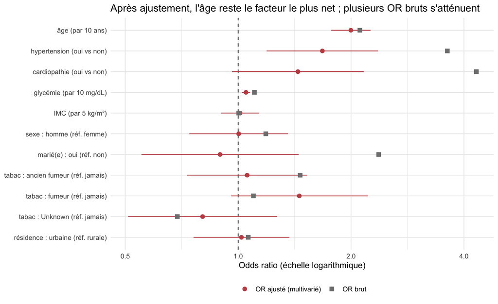

```r
forest_df <- adj_tbl %>%
  left_join(crude_tbl %>% select(terme, OR_brut = OR), by = "terme") %>%
  mutate(etiquette = unname(labels_map[terme]),
         etiquette = factor(etiquette, levels = rev(etiquette)))     # 第一个变量在最上面 / 1re variable en haut

# 对数坐标：0.5 与 2 关于 1 对称 / échelle log : 0,5 et 2 symétriques autour de 1
p4 <- ggplot(forest_df) +
  geom_vline(xintercept = 1, linetype = "dashed") +
  geom_segment(aes(x = ic95_bas, xend = ic95_haut, y = etiquette, yend = etiquette), colour = "#C44E52") +
  geom_point(aes(x = OR,      y = etiquette, colour = "OR ajusté (multivarié)", shape = "OR ajusté (multivarié)"), size = 2.5) +
  geom_point(aes(x = OR_brut, y = etiquette, colour = "OR brut",                shape = "OR brut"),                size = 2.5) +
  scale_colour_manual(values = c("OR ajusté (multivarié)" = "#C44E52", "OR brut" = "grey50"), name = NULL) +
  scale_shape_manual(values = c("OR ajusté (multivarié)" = 16, "OR brut" = 15), name = NULL) +
  scale_x_log10(breaks = c(0.5, 1, 2, 4)) +
  labs(x = "Odds ratio (échelle logarithmique)", y = NULL,
       title = "Après ajustement, l'âge reste le facteur le plus net ; plusieurs OR bruts s'atténuent") +
  theme(legend.position = "bottom")
p4
```

```r
ggsave(file.path(fig_dir, "fig4_forest_plot.png"), p4, width = 9.5, height = 5.5, dpi = 150)
```

## 6.8 危险因素的叠加（Q4）/ Cumul des facteurs de risque

```r
adults <- adults %>%
  mutate(n_risque = hypertension + heart_disease,          # 高血压 + 心脏病 的个数 (0/1/2) / nb de facteurs
         age_band = ifelse(age >= 65, "65+", "18-64"))

cumul <- adults %>%
  group_by(age_band, n_risque) %>%
  summarise(n = n(), evenements = sum(stroke), .groups = "drop") %>%
  add_rate()
kt(cumul)
```

| age_band | n_risque | n | evenements | taux_pct | ic95_bas | ic95_haut |
| --- | --- | --- | --- | --- | --- | --- |
| 18-64 | 0 | 2883 | 61 | 2.12 | 1.65 | 2.71 |
| 18-64 | 1 | 324 | 25 | 7.72 | 5.28 | 11.14 |
| 18-64 | 2 | 19 | 2 | 10.53 | 2.94 | 31.39 |
| 65+ | 0 | 662 | 86 | 12.99 | 10.64 | 15.77 |
| 65+ | 1 | 320 | 62 | 19.38 | 15.42 | 24.06 |
| 65+ | 2 | 45 | 11 | 24.44 | 14.24 | 38.67 |

```r
cat("➜ 注意 n 很小的格子（如 18-64 岁且两个因素都有），区间很宽，别过度解读。\n")
```

```
## ➜ 注意 n 很小的格子（如 18-64 岁且两个因素都有），区间很宽，别过度解读。
```

```r
cat("➜ Attention aux cases à petit n (18-64 ans avec 2 facteurs) : IC très larges, ne pas sur-interpréter.\n")
```

```
## ➜ Attention aux cases à petit n (18-64 ans avec 2 facteurs) : IC très larges, ne pas sur-interpréter.
```

# Étape 6bis — Analyse de sensibilité / 敏感性分析：结论是否依赖我的处理方式？

**中文**：BMI 缺失很可能非随机，所以**没有一种处理方法是「正确」的**。做 4 种处理，比较关键 OR 是否稳定——在各种合理处理下都成立的结论才可信。 **Français** : le manque d’IMC étant probablement non aléatoire, **aucune méthode n’est « la bonne »**. On en compare 4 ; une conclusion n’est crédible que si elle résiste.

| # | 方法 / Méthode |
| --- | --- |
| 1 | 完整案例：删除 BMI 缺失行 / cas complets |
| 2 | 全体中位数填补 / imputation par la médiane globale |
| 3 | 按年龄组中位数填补 / imputation par la médiane du groupe d’âge |
| 4 | 中位数填补 + 「BMI 缺失」指示变量 / médiane + indicateur « IMC manquant » |

*(进阶 / Avancé : 多重填补 MICE，包 `mice` / imputation multiple MICE, package `mice`)*

```r
# 拟合并返回：OR 表、样本数、事件数 / ajuste et renvoie : tableau d'OR, n, événements
run_model <- function(d, formula = adj_formula) {
  fit <- glm(formula, data = d, family = binomial)     # glm 默认删除含 NA 的行 = 完整案例 / glm retire les NA = cas complets
  list(or = or_table(fit), n = nobs(fit), events = sum(fit$y))
}

# 方法 1：完整案例 / cas complets
d1 <- model_df

# 方法 2：全体中位数 / médiane globale
d2 <- model_df %>% mutate(bmi5 = ifelse(is.na(bmi5), median(bmi5, na.rm = TRUE), bmi5))

# 方法 3：按年龄组中位数 / médiane par groupe d'âge
d3 <- model_df %>%
  group_by(age_group) %>%
  mutate(bmi5 = ifelse(is.na(bmi5), median(bmi5, na.rm = TRUE), bmi5)) %>%
  ungroup()

# 方法 4：中位数 + 缺失指示变量 / médiane + indicateur de manque
d4 <- d2 %>% mutate(bmi_manquant = as.integer(is.na(bmi)))   # 原始 bmi 列未被修改 / la colonne bmi d'origine est intacte
formula4 <- update(adj_formula, . ~ . + bmi_manquant)

res <- list("1. Cas complets"          = run_model(d1),
            "2. Médiane globale"       = run_model(d2),
            "3. Médiane par âge"       = run_model(d3),
            "4. Médiane + indicateur"  = run_model(d4, formula4))

key <- c("age10", "hypertension", "heart_disease", "glucose10", "bmi5")
summary_or <- sapply(res, function(r) r$or$OR[match(key, r$or$terme)])
rownames(summary_or) <- key
cat("关键变量的调整后 OR / OR ajustés des variables clés :\n")
```

```
## 关键变量的调整后 OR / OR ajustés des variables clés :
```

```r
kt(summary_or, 3)
```

|  | 1. Cas complets | 2. Médiane globale | 3. Médiane par âge | 4. Médiane + indicateur |
| --- | --- | --- | --- | --- |
| age10 | 1.998 | 2.042 | 2.043 | 2.049 |
| hypertension | 1.677 | 1.478 | 1.476 | 1.386 |
| heart_disease | 1.443 | 1.330 | 1.331 | 1.236 |
| glucose10 | 1.049 | 1.043 | 1.043 | 1.039 |
| bmi5 | 1.012 | 1.009 | 1.013 | 1.031 |

```r
cat("\n各方法使用的样本 / Échantillon utilisé par chaque méthode :\n")
```

```
##
## 各方法使用的样本 / Échantillon utilisé par chaque méthode :
```

```r
kt(sapply(res, function(r) c(n = r$n, AVC = r$events)), 0)
```

|  | 1. Cas complets | 2. Médiane globale | 3. Médiane par âge | 4. Médiane + indicateur |
| --- | --- | --- | --- | --- |
| n | 4072 | 4253 | 4253 | 4253 |
| AVC | 208 | 247 | 247 | 247 |

```r
cat("\n➜ 方法 1 少了 181 人(含 39 例中风)；2-4 保留全部成人 / La méthode 1 perd 181 adultes (dont 39 AVC) ; 2-4 gardent tous les adultes.\n")
```

```
##
## ➜ 方法 1 少了 181 人(含 39 例中风)；2-4 保留全部成人 / La méthode 1 perd 181 adultes (dont 39 AVC) ; 2-4 gardent tous les adultes.
```

```r
or_manquant <- res[[4]]$or$OR[res[[4]]$or$terme == "bmi_manquant"]
cat(sprintf("\n方法 4 中「BMI 缺失」的 OR / OR de l'indicateur « IMC manquant » : %.2f\n", or_manquant))
```

```
##
## 方法 4 中「BMI 缺失」的 OR / OR de l'indicateur « IMC manquant » : 3.57
```

```r
cat("➜ 先看 age10、hypertension、heart_disease 的 OR 在 4 种处理下是否相近；再看 bmi5 是否稳定。\n")
```

```
## ➜ 先看 age10、hypertension、heart_disease 的 OR 在 4 种处理下是否相近；再看 bmi5 是否稳定。
```

```r
cat("➜ Vérifiez d'abord si les OR de age10, hypertension, heart_disease sont proches d'une méthode à l'autre ; puis ceux de bmi5.\n")
```

```
## ➜ Vérifiez d'abord si les OR de age10, hypertension, heart_disease sont proches d'une méthode à l'autre ; puis ceux de bmi5.
```

### ✍️ 你来练习 / À vous de jouer

1. **中文**：哪些 OR 在 4 种方法下几乎不变？哪个变化最大？报告里如何描述「结论的稳健性」？ **Français** : quels OR restent stables ? lequel varie le plus ? Comment décrire la « robustesse » ?
2. **中文**：把 `heart_disease` 和 `hypertension` 从 `adj_formula` 里去掉再拟合，`age10`、`glucose10`、`bmi5` 的 OR 怎么变？这与「中介变量」有什么关系？ **Français** : retirez `heart_disease` et `hypertension` de `adj_formula` : comment changent les OR de `age10`, `glucose10`, `bmi5` ? Lien avec les variables médiatrices ?

# Étape 7 — Visualisation / 第 7 步：可视化原则

**中文**（对照 `figures/` 文件夹里的 5 张图） 1. **一张图只讲一件事**；标题写**结论**，不是变量名。 2. **永远标注 n**；率要配置信区间。 3. 分层对比图（图 3）与森林图（图 4）最能体现「分析师思维」。 4. 避免默认配色、3D、饼图；比较用并排柱或点图。 5. 图中文字要让**不懂统计的人**也能读懂。

**Français** (à comparer avec les 5 figures du dossier `figures/`) 1. **Une figure = un message** ; le titre énonce la **conclusion**. 2. **Toujours afficher n** ; taux avec IC. 3. Fig. 3 (stratifiée) et Fig. 4 (forest plot) montrent le mieux une « pensée d’analyste ». 4. Éviter couleurs par défaut, 3D, camemberts ; comparer avec barres ou points. 5. Texte lisible par **un non-statisticien**.

# Étape 8 — Conclusions, limites, journal / 第 8 步：结论、局限性、决策日志

## 8.1 结论模板（请用自己的话完成）/ Modèle de conclusion

**中文**：用「关联」，不用「导致」。每条结论写出：**发现 + 证据（数字）+ 可信度 + 限制**。 **Français** : « association », jamais « cause ». Chaque conclusion : **constat + preuve chiffrée + confiance + limite**.

1. **年龄 / Âge** : 中风率从 **% (**_岁) 升到 __% (*岁)；调整后每增加 10 岁 OR =* 。
2. **高血压 / 心脏病 / Hypertension / cardiopathie** : 粗 OR ___ → 调整后 OR ___（变弱 / 稳定 ?）。
3. **婚姻 / Mariage** : 粗 OR ___ → 年龄调整后 OR ___ → 解释：年龄的替身。
4. **吸烟 / Tabac** : 反直觉发现 *；我检验了* ；无法检验的是 ___。
5. **BMI 缺失 / IMC manquant** : 4 种处理下结论 [稳定 / 不稳定 · stable / instable]。

## 8.2 局限性 / Limites

- **横断面观察数据**：无时间先后，只能谈关联；可能存在反向因果。 *Données transversales observationnelles : pas de chronologie ; causalité inverse possible.*
- **样本很可能不是随机人群样本**：中风率 ≈ 5%（成人 ≈ 5.8%）远高于一般人群，不能用来估计患病率。 *Échantillon probablement non aléatoire : taux d’AVC (~5 %) très supérieur à la population générale → aucune estimation de prévalence.*
- **事件数少**：仅 249 例中风，许多亚组事件极少，区间宽。 *Peu d’événements : 249 AVC ; nombreux sous-groupes avec très peu d’événements.*
- **变量定义不明**：血糖（空腹？）、高血压（诊断？）、吸烟 `Unknown`。 *Définitions floues : glycémie (à jeun ?), hypertension (diagnostiquée ?), tabac `Unknown`.*
- **BMI 缺失很可能非随机**：任何处理都可能有偏（见敏感性分析）。 *IMC manquant probablement non aléatoire : tout traitement peut biaiser.*
- **缺少关键变量**：家族史、用药、饮食、运动、吸烟量（包年）、中风类型与发病时间。 *Variables absentes : antécédents familiaux, traitements, alimentation, activité, paquets-années, type et date de l’AVC.*
- **数据集来源与采集方式未充分说明**，外推需谨慎。 *Provenance et collecte insuffisamment documentées : prudence pour toute généralisation.*

## 8.3 决策日志 / Journal de décisions

| # | 决定 / Décision | 备选 / Alternatives | 理由 / Raison | 已验证影响？/ Impact vérifié ? |
| --- | --- | --- | --- | --- |
| 1 | 剔除 `gender=Other` | 保留为单独类别 | 仅 1 行 | 否（可忽略） |
| 2 | 主分析限成人 ≥18 | 全人群 | 儿童变量无意义、事件极少 | 部分（图 1 显示儿童几乎为 0） |
| 3 | BMI 缺失：完整案例为主 | 中位数 / 指示变量 | 缺失很可能非随机 | ✅ 见 6bis |
| 4 | 年龄分 3 层做分层 | 更细的层 | 各层要有足够事件数 | 可自行尝试 |
| 5 | OR 用「每 10 岁 / 10 mg/dL / 5 kg/m²」 | 分箱 | 保留信息，易解释 | 可用分箱版本对照 |
| 6 |  |  |  |  |

## 8.4 「审计 AI」清单 / Liste d’« audit de l’IA »

**中文**：让 AI 生成一版「标准流程」，逐条检查并**记录你发现的问题和你的修正**——这是你的作品集亮点。 **Français** : demandez à une IA un pipeline « standard », vérifiez chaque point et **documentez vos corrections** — c’est un atout pour votre portfolio.

- 是否悄悄删除了 BMI 缺失行？ / A-t-elle supprimé silencieusement les lignes sans IMC ?
- R 里是否漏掉 `na = "N/A"`，导致 bmi 变成文字？ / En R, a-t-elle oublié `na = "N/A"` (bmi lu comme texte) ?
- 是否对儿童套用成人 BMI 标准？ / Seuils d’IMC adultes appliqués aux enfants ?
- 是否把 `Unknown` 当成普通吸烟类别？ / `Unknown` traité comme une modalité ordinaire ?
- 是否比较「数量」而不是「率」？ / Effectifs comparés au lieu de taux ?
- 是否做了分层/调整？是否把中介变量当混杂因素？ / Stratification/ajustement ? Médiatrice traitée comme confondant ?
- 结论里有没有「导致 / cause / provoque」？ / Les mots « cause / provoque » apparaissent-ils ?
- 是否用机器学习「准确率」掩盖 4.9% 的类别不平衡？ / « Accuracy » flatteuse masquant le déséquilibre (4,9 %) ?

## 8.5 下一步 / Pistes suivantes

1. **中文**：写一页「非技术读者摘要」（不出现 OR 与 p 值）。 **Français** : résumé d’une page pour non-spécialistes (sans OR ni p-valeur).
2. **中文**：（进阶）预测模型：AUC、PR 曲线、校准；说明年龄单变量已能达到多少。 **Français** : (avancé) modèle prédictif : AUC, courbe PR, calibration ; ce que l’âge seul permet déjà.
3. **中文**：（进阶）多重填补 `mice`、bootstrap 置信区间。 **Français** : (avancé) imputation multiple `mice`, IC par bootstrap.

# ✅ 自动验算 / Vérification automatique

**中文**：下面的参考值来自我在 Python 中对同一份数据的独立计算。全部显示 ✔ 说明你的 R 流程正确；出现 ✘ 说明某一步与预期不符（最常见原因：读入时 `N/A` 没处理好，或分段边界改动过）。 **Français** : les valeurs de référence proviennent d’un calcul indépendant en Python sur les mêmes données. Tout ✔ = votre pipeline R est correct ; un ✘ signale un écart (cause fréquente : `N/A` mal lu, ou bornes de strates modifiées).

```r
check <- function(label, got, expected, tol = 0.01) {
  cat(sprintf("%s %-46s obtenu %9.3f | attendu %9.3f\n",
              ifelse(abs(got - expected) <= tol, "✔", "✘"), label, got, expected))
}

check("IMC manquants (données brutes)",            sum(is.na(df_raw$bmi)), 201, 0)
```

```
## ✔ IMC manquants (données brutes)                obtenu   201.000 | attendu   201.000
```

```r
check("Taux AVC si IMC manquant (%)",              bmi_check$taux_AVC_pct[bmi_check$bmi_missing], 19.90, 0.05)
```

```
## ✔ Taux AVC si IMC manquant (%)                   obtenu    19.900 | attendu    19.900
```

```r
check("Taux AVC si IMC présent (%)",               bmi_check$taux_AVC_pct[!bmi_check$bmi_missing], 4.26, 0.05)
```

```
## ✔ Taux AVC si IMC présent (%)                   obtenu     4.257 | attendu     4.260
```

```r
check("Adultes (>=18)",                            nrow(adults), 4253, 0)
```

```
## ✔ Adultes (>=18)                                 obtenu  4253.000 | attendu  4253.000
```

```r
check("AVC chez les adultes",                      sum(adults$stroke), 247, 0)
```

```
## ✔ AVC chez les adultes                           obtenu   247.000 | attendu   247.000
```

```r
check("Taux d'AVC 70-79 ans (%)",                  age_rates$taux_pct[age_rates$modalite == "70-79"], 16.52, 0.05)
```

```
## ✔ Taux d'AVC 70-79 ans (%)                       obtenu    16.520 | attendu    16.520
```

```r
check("Taux d'AVC 80+ ans (%)",                    age_rates$taux_pct[age_rates$modalite == "80+"], 21.51, 0.05)
```

```
## ✔ Taux d'AVC 80+ ans (%)                         obtenu    21.505 | attendu    21.510
```

```r
check("OR brut mariage",                           or_brut_mar["OR"], 2.27, 0.01)
```

```
## ✔ OR brut mariage                                obtenu     2.270 | attendu     2.270
```

```r
check("OR ajusté (MH) mariage",                    mh$estimate, 0.91, 0.01)
```

```
## ✔ OR ajusté (MH) mariage                        obtenu     0.905 | attendu     0.910
```

```r
check("Cas complets (modèle)",                     nobs(fit_adj), 4072, 0)
```

```
## ✔ Cas complets (modèle)                         obtenu  4072.000 | attendu  4072.000
```

```r
check("OR ajusté age10",                           adj_tbl$OR[adj_tbl$terme == "age10"], 1.998, 0.01)
```

```
## ✔ OR ajusté age10                               obtenu     1.998 | attendu     1.998
```

```r
check("OR ajusté hypertension",                    adj_tbl$OR[adj_tbl$terme == "hypertension"], 1.677, 0.01)
```

```
## ✔ OR ajusté hypertension                        obtenu     1.677 | attendu     1.677
```

```r
check("OR ajusté heart_disease",                   adj_tbl$OR[adj_tbl$terme == "heart_disease"], 1.443, 0.01)
```

```
## ✔ OR ajusté heart_disease                       obtenu     1.443 | attendu     1.443
```

```r
check("OR hypertension (médiane globale)",         summary_or["hypertension", 2], 1.478, 0.01)
```

```
## ✔ OR hypertension (médiane globale)             obtenu     1.478 | attendu     1.478
```

```r
check("OR hypertension (médiane + indicateur)",    summary_or["hypertension", 4], 1.386, 0.01)
```

```
## ✔ OR hypertension (médiane + indicateur)        obtenu     1.386 | attendu     1.386
```

```r
check("OR de l'indicateur « IMC manquant »",       or_manquant, 3.57, 0.02)
```

```
## ✔ OR de l'indicateur « IMC manquant »          obtenu     3.570 | attendu     3.570
```

**参考值（全部来自 Python 独立计算，允许 ±0.01 的舍入差异）/ Valeurs de référence** :

| 项目 / Élément | 参考值 / Valeur |
| --- | --- |
| 行数、中风数 / lignes, AVC | 5 110 ; 249 (4,87 %) |
| BMI 缺失 / IMC manquants | 201 ；缺失者中风率 19,90 % vs 4,26 % |
| 成人 / adultes | 4 253 人，247 例中风 (5,81 %) |
| 各年龄段中风率 / taux par âge | <18: 0,23 · 18-29: 0,00 · 30-39: 0,92 · 40-49: 1,64 · 50-59: 5,76 · 60-69: 7,57 · 70-79: 16,52 · 80+: 21,51 (%) |
| 婚姻 OR / OR mariage | 粗 2,27 [1,51–3,41] → MH 0,91 [0,59–1,40] |
| 调整后 OR / OR ajustés | age10 1,998 · hypertension 1,677 · heart_disease 1,443 · glucose10 1,049 · bmi5 1,012 |
| 敏感性：高血压 OR / sensibilité : OR hypertension | 1,677 · 1,478 · 1,476 · 1,386 |